# Exploring the BRFSS data

## Setup

### Load packages

```r
library(ggplot2)
library(dplyr)
library(gridExtra)
```

### Load data

```r
load("brfss2013.RData")
```

## Part 1: Data

The sample is a good representative of the population . Interviewers used stratified random sampling to conduct both landline telephone and cellular telephone-based surveys. Whereas randomly selected adults in households used the landline means, others who resided in private-residences/college-housing participated by using a cellular telephones. A wide coverage of selected questions was set up during the data collection to adress most essential factors hence well adressing topic of interest and consequently generalizable to US population.

It is not possible to infer causality since the experiment was done over a chosens strata of people; Hence different experiment groups were not randomly selected but were prechosen. It is clear that this study is observational and not experimental. There were levels of conveniences adopted as research was clustered into telephone or cellular with voluntary particpation; In addition, some reseacrch was categorically approached based on certain selection criteria and not random. These factors may raise bias when attempting to estimate the population parameters. However the bias problem was fairly resolved by introducing the weighting technique and by collecting a large volume of data over a wide variety of features.

It is therefore very clear that this random sample is appropriate for estimating the population parameters.

## Part 2: Research questions

**Research quesion 1:**

Investigate the effect of exercise levels `(X_pa300r2)` on health status `(genhlth)` of US population `(count)`. Clearly illustrate Its variability across exercise levels and health categories respectively.

**Research quesion 2:**

Illustrate the variability `(h_count)` of health report `(X_rfhlth)` across the states `(X_state)`. Compare the distributions of the health categories across the states.

**Research quesion 3:**

How is the population `(counts_e, counts_se)` distributed across the different employment categories `(employ1)`? Investigate whether there exists gender `(sex)` imbalance across the employment categories `(employ1)`.

## Part 3: Exploratory data analysis

**Research quesion 1:**

```r
# The counts of different views of the people on their General Health status
health_excercise <- brfss2013 %>%
  group_by(X_pa300r2, genhlth) %>%
  filter(!is.na(genhlth), !is.na(X_pa300r2))
#Table summary for Excellent health
health_excercise %>%
  filter(genhlth == "Excellent") %>%
  summarise(h_count = n())
```

```
## Source: local data frame [3 x 3]
## Groups: X_pa300r2 [?]
##
## # A tibble: 3 x 3
##       X_pa300r2   genhlth h_count
##          <fctr>    <fctr>   <int>
## 1  301+ minutes Excellent   31183
## 2 1-300 minutes Excellent   27638
## 3     0 minutes Excellent   12605
```

```r
# Table for the poor health
health_excercise %>%
  filter(genhlth == "Poor") %>%
  summarise(h_count = n())
```

```
## Source: local data frame [3 x 3]
## Groups: X_pa300r2 [?]
##
## # A tibble: 3 x 3
##       X_pa300r2 genhlth h_count
##          <fctr>  <fctr>   <int>
## 1  301+ minutes    Poor    3420
## 2 1-300 minutes    Poor    5145
## 3     0 minutes    Poor   15176
```

The table results above show brief summary of the extreme health categories `(Excellent` and `Poor)`. As shown in the tables, many people with no exercises have Poor health. On the other hand perfect health record is observed in people with great exercise habbits.

```r
p1 <- ggplot(data = health_excercise, aes(x = X_pa300r2, fill = genhlth)) +
  labs(title = "Heath variability w.r.t exercise levels") +
  labs(x = "a)    Physical activity minutes") + labs(y = "# people") +
  geom_bar(position = "stack") + theme(axis.text.x=element_text(angle = 90, hjust = 1)) +
  theme(plot.title = element_text(hjust = 0.5))
```

```r
p2 <- ggplot(data = health_excercise, aes(x = genhlth, fill = X_pa300r2)) +
  labs(title = "Exercise level effect on health status") +
  labs(x = "b)   health status") + labs(y = "# Effect rate") +
  geom_bar(position = "fill") + theme(axis.text.x=element_text(angle = 90, hjust = 1)) +
  theme(plot.title = element_text(hjust = 0.5))
```

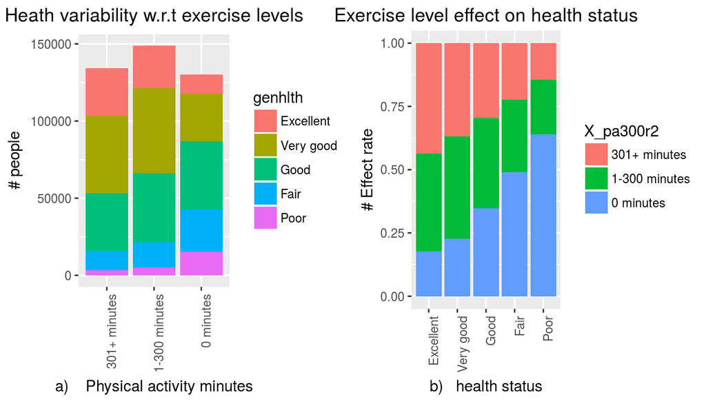

```r
grid.arrange(p1,p2, ncol=2)
```

It is observable from the two grpahs that exercises have positive influence on health. As illustrated in the graphs, `poor health` is more visible among those who do not participate in physical exercises and this gradually decreases as exercise level rises. Conversely, `great health` is clearly observed in those participating in the exercises with most healthy people in the `301+minutes` exercise level. Generally, the number of people are uniformly distributed across physical exercise categories.

**Research quesion 2:**

```r
# Counts of adults with bad and good health report across the states
state_health <- brfss2013 %>%
  group_by(X_state, X_rfhlth) %>%
  filter(!is.na(X_state),!is.na(X_rfhlth)) %>%
  summarise(count = n())
```

```r
gbh <- state_health %>%
  filter(X_rfhlth == "Good or Better Health") %>%
  group_by(X_state, X_rfhlth) %>%
  arrange(desc(count))
head(gbh)
```

```
## Source: local data frame [6 x 3]
## Groups: X_state, X_rfhlth [6]
##
## # A tibble: 6 x 3
##         X_state              X_rfhlth count
##          <fctr>                <fctr> <int>
## 1       Florida Good or Better Health 25529
## 2        Kansas Good or Better Health 19317
## 3      Nebraska Good or Better Health 14321
## 4     Minnesota Good or Better Health 12395
## 5 Massachusetts Good or Better Health 12357
## 6      Colorado Good or Better Health 11694
```

As shown above `Good or Better Health` type is lead by `Florida` and `Kansas` respectively.

```r
fph <- state_health %>%
  filter(X_rfhlth == "Fair or Poor Health") %>%
  group_by(X_state, X_rfhlth) %>%
  arrange(desc(count))
head(fph)
```

```
## Source: local data frame [6 x 3]
## Groups: X_state, X_rfhlth [6]
##
## # A tibble: 6 x 3
##         X_state            X_rfhlth count
##          <fctr>              <fctr> <int>
## 1       Florida Fair or Poor Health  7776
## 2        Kansas Fair or Poor Health  3911
## 3      Kentucky Fair or Poor Health  2938
## 4      Nebraska Fair or Poor Health  2785
## 5 Massachusetts Fair or Poor Health  2685
## 6          Ohio Fair or Poor Health  2494
```

The health type `Fair or Poor Health` is also dominated by `Florida` and `Kansas` respectively.

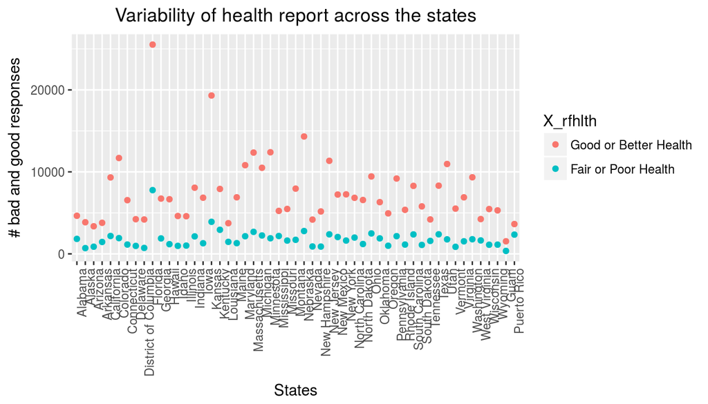

```r
ggplot(data = state_health, aes(x = X_state, y = count, color = X_rfhlth)) +
  labs(title = "Variability of health report across the states") +
  labs(x = "States") + labs(y = "# bad and good responses") +
  geom_point() + theme(axis.text.x=element_text(angle = 90, hjust = 1)) +
  theme(plot.title = element_text(hjust = 0.5))
```

The scatter plot illustrates that `Good or Better Health` report clearly surpasses `Fair or Poor Health` health across the different states. Exceptionally large mass is observed in `Florida` with health category `Good or Better Health`. Flroida also registered the largest case of `Fair or Poor Health` category. This probably implies that Florida is highly populated. Generally the `Fair or Poor Health` health category cases have low variability across the states and more uniformly distributed whereas `Good or Better Health` experiences high variability. It is probable that `Florida` and `Kansas` states top the list of best and worst health cases because of their high population. This investigation is not enough for absolute conclusion but provides good evidence that more people are in good health than in bad health across the states.

**Research quesion 3:**

```r
# Employment levels
brf1 <- brfss2013 %>%
  filter(!is.na(employ1), !is.na(sex))
```

```r
# Number of people per empoyment type
brf1 %>%
  group_by(employ1) %>%
  summarise(counts_e = n()) %>%
  arrange(desc(counts_e))
```

```
## # A tibble: 8 x 2
##                            employ1 counts_e
##                             <fctr>    <int>
## 1               Employed for wages   202200
## 2                          Retired   138259
## 3                    Self-employed    39832
## 4                   Unable to work    37453
## 5                      A homemaker    31646
## 6   Out of work for 1 year or more    14073
## 7                        A student    12682
## 8 Out of work for less than 1 year    12241
```

This table summarises the population distribution across different employment types. It is clear that `Employed for wages` tops the list whereas `Out of work for less than 1 year` has the lowest number of people.

```r
# Number of males and females per employment type
brf1 %>%
  group_by(sex, employ1) %>%
  summarise(counts_se = n()) %>%
  arrange(desc(counts_se))
```

```
## Source: local data frame [16 x 3]
## Groups: sex [2]
##
## # A tibble: 16 x 3
##       sex                          employ1 counts_se
##    <fctr>                           <fctr>     <int>
##  1 Female               Employed for wages    111145
##  2   Male               Employed for wages     91055
##  3 Female                          Retired     83366
##  4   Male                          Retired     54893
##  5 Female                      A homemaker     31036
##  6 Female                   Unable to work     24086
##  7   Male                    Self-employed     23081
##  8 Female                    Self-employed     16751
##  9   Male                   Unable to work     13367
## 10 Female   Out of work for 1 year or more      8243
## 11 Female                        A student      7300
## 12 Female Out of work for less than 1 year      6532
## 13   Male   Out of work for 1 year or more      5830
## 14   Male Out of work for less than 1 year      5709
## 15   Male                        A student      5382
## 16   Male                      A homemaker       610
```

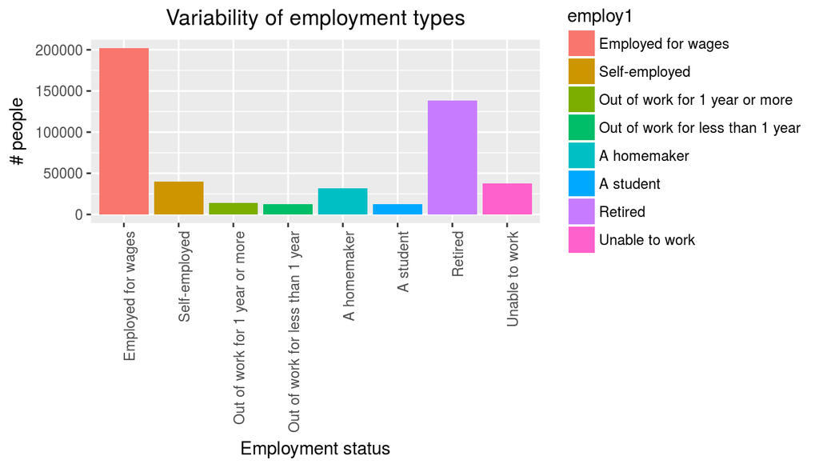

```r
# plots general employee variability
p1 <- ggplot(data = brf1, aes(x = employ1, fill = employ1)) +
  labs(title = "Variability of employment types") +
  labs(x = "Employment status") + labs(y = "# people") +
  geom_bar() + theme(plot.title = element_text(hjust = 0.5))
p1 + theme(axis.text.x=element_text(angle = 90, hjust = 1))
```

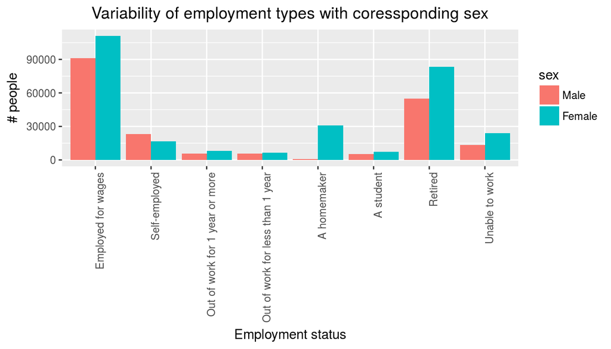

```r
#plots variability based on sex
p2 <-ggplot(data = brf1, aes(x = employ1, fill = sex)) +
  labs(title = "Variability of employment types with coressponding sex") +
  labs(x = "Employment status") + labs(y = "# people") +
  geom_bar(position = "dodge") + theme(plot.title = element_text(hjust = 0.5))
p2 + theme(axis.text.x=element_text(angle = 90, hjust = 1))
```